# MD simulation and machine learning aid peptide design

**Introduction**:

The combination of molecular dynamics simulations and machine learning can be utilized for the development of functional peptides. Structural-function analysis enables the design of protein materials. The research conducted peptide structural changes using molecular dynamics simulations and machine learning methods. Peptides exhibit different structures in solution and on solid surfaces. Mechanistic studies were performed by designing peptides with regular sequences.

**Methods and Problem**:

Molecular dynamics simulations provided structural parameters of peptides that are difficult to measure experimentally, such as the proportions of different secondary structures, charges, radius of gyration (Rg) in solution and on surfaces, solvent-accessible surface area (SASA), and number of hydrogen bonds. The regression relationship between these structural parameters and peptide grafting density was investigated using the random forest machine learning algorithm. The importance ranking of selected factors was determined. By combining molecular dynamics simulations with experimental results, the intrinsic factors influencing peptide immobilization in experiments were analyzed, and the significance of peptide size on experimental synthesis efficiency was revealed using machine learning. The machine learning results indicated that larger peptides tend to bind to surfaces, thereby increasing their reaction opportunities.

**Conclusions**:

The impact of dynamic structural changes of peptides on the grafting density of functionalized biomaterial surfaces was elucidated through calculations. Additionally, the research provided insights into the design of protein peptides with typical structural features. This study offers an effective strategy for the development of implants with peptide-modified surfaces.

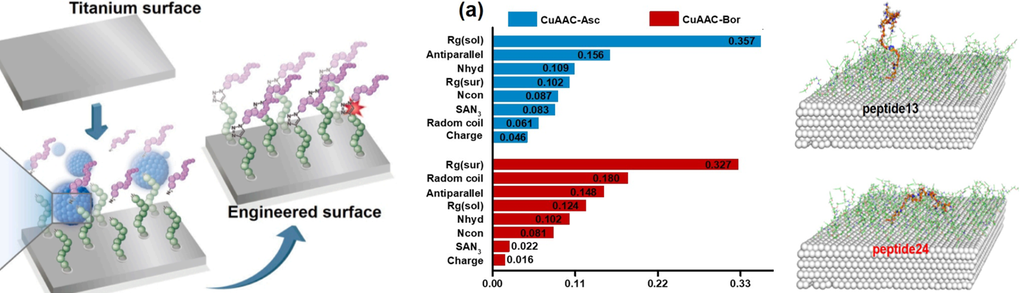

**简介**：

分子动力学模拟和机器学习结合的方法可以用于开发具有广谱改性的新型多肽表面的植入物。通过分析结构-功能的分析，可以实现对蛋白质材料的设计。利用分子动力学模拟和机器学习方法进行了蛋白多肽结构变化的研究。蛋白质在溶液中和固体表面会表现出不同的结构，通过设计具有规则序列的多肽，进行了基于机理的研究。

**方法和问题**：

分子动力学模拟获得了实验过程中难以测量的多肽不同二级结构的比例、所带的电荷、多肽在溶液中及在表面的半径Rg、溶液可及表面积SASA、多肽的氢键数目等结构参数。然后利用随机森林的机器学习算法研究多肽的结构参数与多肽接枝密度之间的回归关系。对选定的影响因素进行了特征的重要性排序。通过分子动力学模拟和实验结果的结合，分析了实验中固定肽的内在影响因素，并通过机器学习的方法揭示了肽大小对实验合成效率的重要性。机器学习的结果表明，较大的肽更倾向于与表面结合，从而增加它们的反应机会。

**结论**： 通过计算阐明了多肽的动态结构变化对构建功能化生物材料表面接枝密度的影响，以及如何设计具有典型结构特征的蛋白多肽种类。这项研究为开发具有肽改性表面的新型植入物提供了有效的策略。

Return to Research.